# Data Visualization: Critique and Redesign

Authors

Liew Jia Rong (2501090)

Alyssa Kwek Li Yun (2403480)

Su Myat Nhwe (2403062)

Woo Wei Qin (2402934)

Teo Xue Ling Sharlene (2503489)

Published

March 6, 2026

# 1 Executive Summary

This proposal evaluates the effectiveness of a 4-dimensional bubble chart used to present “Technical Layoffs Since the Fed Began Raising Interest Rates” and recommends a redesigned approach that simplifies the visual elements to reveal underlying trends with greater clarity.

# 2 Introduction & Original Visualization

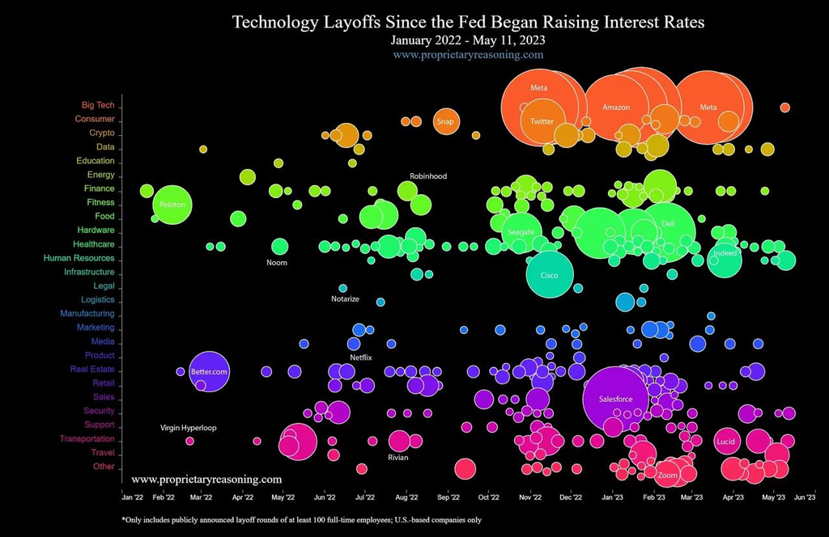

Original Visualisation

## 2.1 Context

The visualisation maps layoff from January 2022 to May 2023 across industry sectors and layoff volume. The x-axis represents chronological progression while the y-axis categorises industry sectors, bubble size indicates the number of employees laid off, and colour differentiates sector groupings. This visualisation was selected because it shows the direct correlation between macroeconomic policy and the stability of the workforce. It demonstrates how the increase in interest rates triggered a contraction in the job market. The visualization attempts to illustrate the impact of tighter financial conditions on employment patterns by displaying an increasing size of layoffs subsequent to the increased interest rates.

## 2.2 Critique of the Original Design

### 2.2.1 Strengths

- **Comprehensive Data Representation:** The visualisation presents layoffs across multiple sectors in a clear timeline, allowing viewers to understand when layoffs occurred and how different industries were affected by the interest rate hikes.
- **Effective Use of Size:** The variation of bubble sizes effectively indicates the scale of layoffs, giving a quick visual cue about the magnitude of job losses in each sector. Larger bubbles naturally draw the attention, making it easier to identify major layoff events at a glance.
- **Strategic Labeling:** By labeling only the most prominent companies like Meta and Amazon, it provides immediate context for massive layoffs while preventing text clutter.
- **Clear Chronological Structure:** The timeline effectively maps the progression of layoffs, highlighting peak periods and allowing viewers to easily correlate job losses with rising interest rates.

### 2.2.2 Weaknesses

Packing four variables into a single chart violates several core data visualization principles:

- **Severe Overplotting and Occlusion:** The large number of overlapping bubbles makes the chart appear cluttered, particularly during peak periods in sectors like Big Tech and Retail. Larger bubbles frequently obscure smaller ones, hiding important data points. Because all industries are displayed in a single space, it creates misleading density, making it incredibly difficult to compare trends within industries or clearly observe patterns for any specific sector over time.
- **The “Area” Perception Problem:** Human perception is not well-suited for comparing differences in area, making it difficult to accurately judge the scale of layoffs when bubbles overlap or are similar in size. This flaw is compounded by a missing size legend and limited precision. Since exact layoff numbers are not immediately visible, viewers cannot easily perform quantitative analysis.
- **High Cognitive Load:** Viewers must interpret multiple visual encodings at the same time, including position, size, color, and timeline. This increases the effort required to parse the chart and extract meaningful insights.
- **Poor Color Accessibility:** The original uses high-saturation neon colours on a black background. While visually striking, it reduces accessibility for colour-vision-deficient viewers and creates perceptual interference between adjacent, overlapping bubbles, further complicating readability.

# 3 Methodology & Improvement Strategy

## 3.1 Planned Improvements

The identified weaknesses in the original visualization directly inform our redesign strategy. Each improvement below is mapped to a specific critique to ensure our changes are purposeful and evidence-based.

### 3.1.1 Small Multiples to Resolve Overplotting and Occlusion

**Weakness addressed:** Severe overplotting and occlusion; misleading density in crowded sectors.

The most critical flaw in the original chart is that large bubbles (e.g., Meta, Amazon) physically obscure dozens of smaller layoff events occurring in the same time window. Our primary redesign strategy is to adopt a **Small Multiples** layout — a grid of individual, aligned scatter plots, one per major industry sector.

By separating each sector into its own panel, every layoff event becomes visible and individually legible. Axes are kept consistent across all panels, allowing meaningful cross-sector comparison while eliminating occlusion entirely. This approach follows Tufte’s principle of maximising the data-ink ratio by removing visual clutter without losing any information.

### 3.1.2 Replacing Raw Bubble Size with a Clearer Visual Encoding

**Weakness addressed:** The “Area” Perception Problem.

Human perception is known to be poor at accurately comparing 2D areas (Cleveland & McGill, 1984). In the original chart, viewers must estimate and compare bubble sizes to understand the scale of layoffs — a cognitively unreliable task, especially when bubbles overlap.

Within each Small Multiples panel, we will retain bubble size as a secondary encoding for layoff count, but supplement it with a **colour gradient scaled to layoff magnitude** (lighter = smaller layoff, darker = larger layoff). This dual encoding (size + colour intensity) gives viewers two independent perceptual cues for the same variable, improving accuracy of magnitude judgements. A shared, clearly labelled legend will accompany all panels.

### 3.1.3 Reducing Cognitive Load through Layout and Annotation

**Weakness addressed:** High cognitive load from tracking four variables simultaneously.

The original chart forces the viewer to cross-reference the Y-axis label, the X-axis timeline, the bubble size, and the colour legend all at once. Our redesign reduces this burden in two ways:

- **Panel titles** replace the need to read the Y-axis for every data point — each sector panel is self-labelled.
- **Annotation of key events** (e.g., Fed rate hike dates marked with a vertical reference line) will be added to contextualise the temporal narrative directly on the chart, removing the need for the viewer to recall external context.

This results in a more guided, lower-effort reading experience that still preserves the full analytical depth of the original.

### 3.1.4 Standardised, Accessible Colour Palette

**Weakness addressed:** The original uses high-saturation neon colours on a black background, which is visually striking but reduces accessibility for colour-vision-deficient viewers and creates perceptual interference between adjacent bubbles.

We will replace the original palette with a **standardised, perceptually uniform colour scheme** (e.g., using ColorBrewer-compatible palettes available in `ggplot2`). Each sector panel will use a consistent base colour, with intensity encoding layoff magnitude as described above. A white or light grey background will replace the black backdrop to improve contrast and readability in both screen and print contexts.

## 3.2 Data Source

- **Primary Source:** https://www.kaggle.com/datasets/theakhilb/layoffs-data-2022  
  Data will be extracted from the Kaggle dataset, which contains detailed records of layoffs across various industries, including dates, company names, and layoff counts. Unlike the original visualisation which focused only on U.S. based companies, this dataset provides a global perspective, documenting layoff events internationally.

## 3.3 Data Preparation

The initial step involves extracting the original variables (Date, Industry Sector, Layoff Count, and Company) and filtering the dataset for missing values to ensure data quality.

Before we could start building our visualizations, we needed to clean up the raw data. Real-world datasets are rarely perfect right out of the box, and this tech layoffs dataset was no exception.

To make sure our charts would be accurate and easy to read, we took the following steps to prep the data:

Fixing the Dates: In the raw file, the dates were saved as plain text (like “2024-06-05”), which the software can’t automatically recognize as a chronological timeline. We converted these into proper date formats. To make it easier to group our data later, we also extracted the specific “Year” and “Month” into their own separate columns.

Removing the Clutter: The original file contained a lot of extra administrative information that we didn’t need for our visual analysis—like source URLs, exact timestamps of when the data was logged, and long text lists of laid-off employees. We deleted these unnecessary columns to keep our dataset clean and help our code run faster.

Standardizing the Categories: We wanted to compare layoffs across different groups, so we needed to make sure the software correctly recognized text labels like “Industry,” “Country,” and “Funding Stage.” We converted these text columns into standardized categories so that identical labels wouldn’t get accidentally split up by hidden formatting quirks or typos.

Handling Missing Data: You can’t plot a missing number on a graph, and this dataset naturally had a few blank cells. We set a simple rule: if a layoff event was completely missing both the raw number of employees let go and the percentage of the workforce affected, we removed that row. As long as a row had at least one of those two key numbers, we kept it in. This allowed us to clean the data without losing too much valuable information.

Once these steps were complete, the dataset was fully organized and ready to be turned into visual trends.

## 3.4 Visualization Strategy & Final Design Choices

- **Chart Type:** Transitioned from a single, crowded bubble chart to small multiple scatter plots for each sector.
- **Visual Encodings:** The X and Y axes remain consistent across all plots. Bubble size is retained for layoff volume, but with clutter removed, scaling is easier to interpret.
- **Clarity:** Gridlines are softened and the color palette is standardized to ensure final result is aesthetically pleasing and professional.

# 4 Data Analysis Plan

To complement our redesigned visualization, we plan to conduct a set of exploratory data analyses that strengthen the narrative around how interest rate hike influenced layoffs across the tech sector.

The purpose of this analysis is to move beyond descriptive visualization and provide quantitative evidence that supports the patterns observed in both the original and improved visualizations. The planned analyses include:

## 4.1 Analytical Objectives

The analysis will be guided by the following objectives which align with the overall project goal of evaluating how macroeconomic policy may have influenced workforce stability within the technology sector:

- **To examine temporal trends in layoff activity** and determine whether there is a significant escalation in layoff volume following the interest rate increases in 2022.
- **To identify which industries were disproportionately affected**, in terms of both frequency of layoff events and total employees laid off.
- **To compare layoff magnitude across company stages**, such as Post-IPO firms versus earlier-stage startups.
- **To explore the relationship between funding levels and layoff behaviour**, particularly whether companies that raised more capital exhibited different layoff patterns.

### 4.1.1 Time-Series Aggregation

The first analysis we plan to conduct is the aggregation of layoff data on a monthly basis to compute:

- Total number of employees laid off per month
- Number of layoff announcements per month

This will allow us to compare layoff patterns before and after the onset of interest rate hikes. The results will provide empirical support for the narrative presented in the visualization.

### 4.1.2 Industry-Level Comparative Analysis

Next, industry categories will be analysed to determine:

- Total layoffs by industry
- Average layoffs per event
- Relative frequency of layoff announcements

This analysis will reveal whether certain sectors experienced structural vulnerability or whether layoffs were evenly distributed across industries.

### 4.1.3 Company Stage Analysis

Using the `Stage` variable, we would like to compare layoff behaviour across company maturity levels. Specifically, we will examine:

- Mean layoff count per stage
- Distribution of layoff percentages

This comparison may highlight whether publicly listed firms or venture-backed startups responded differently to tightening financial conditions.

### 4.1.4 Exploratory Correlation Analysis

We will conduct an exploration of the relationship between:

- Funds raised
- Layoff count
- Percentage of workforce laid off

Scatterplots and simple correlation measures will be used to investigate potential associations. Our aim is to uncover patterns that may inform the improved visualization design.

## 4.2 Expected Outcome

We believe that the planned analysis will help our team to :

- Provide quantitative validation for trends observed visually.
- Strengthen the interpretability and credibility of the redesigned visualization.
- Improve storytelling beyond the limitations of the original bubble chart.

# 5 Planned Work Distribution

[output not shown]